# Ревью правок — для Павла

Отчёт по правкам от Романа: что сделано, что видно на сайте, что осталось согласовать перед запуском на домен.

Команда разработки (Володя)

2026-05-23

# Ревью правок — moreminsk.by

Срез на **2026-05-23**. Для **Павла Царенка** (бизнес-владелец). Назначение: показать в одном документе все правки по сообщениям Романа от 19 мая, скриншоты текущего состояния сайта и **что нужно согласовать перед запуском на домен**.

> **Контекст.** 19 мая Роман переслал серию голосовых/текстовых правок: убрать «Свадьбу», унифицировать цены (2 ч / 350, 4 ч / 500), убрать вариант «6 часов», по «Свиданию» — от 150, по остальным — от 200, все яхты добавить к каждой услуге, и запустить сайт на домен для индексации. По каждому пункту ниже — что сделано + где это видно.

## 2. Что сделано — по каждому пункту Романа

### 2.2 Цены — «Свидание от 150, остальное от 200»

В карточке каждой услуги показывается **«от X BYN»** (минимальная видимая цена) — клиент сразу понимает порядок:

| Услуга | Было | Стало | Пакеты на странице |
| --- | --- | --- | --- |
| День рождения | от 300 BYN | **от 200 BYN** | 2 ч / 350, 4 ч / 500 |
| Корпоратив | от 600 BYN | **от 200 BYN** | 2 ч / 350, 4 ч / 500 |
| Свидание | от 300 BYN | **от 150 BYN** | 1 ч / 150, 2 ч / 350, 4 ч / 500 |
| Девичник | от 300 BYN | **от 200 BYN** | 2 ч / 350, 4 ч / 500 |
| Фотосессия | от 200 BYN | **от 200 BYN** | 2 ч / 350, 4 ч / 500 |

**Нужно согласовать.** В карточке указано «от 200 BYN», но минимальный пакет на той же странице — 2 ч / 350. Это вопрос «как» мы показываем цену:

- **Вариант А (как сейчас).** «От» = маркетинговая цена-приманка (мы можем оформить отдельный 1-часовой выход или почасовую ставку). Покупатель видит низкую цену в карточке, открывает страницу — видит реальные пакеты от 350.
- **Вариант Б.** Поставить «от 350 BYN» — честно равно минимальному пакету. Карточки выглядят дороже, но не вызывают вопросов «почему не 200, как обещали».

Уточни, какой вариант ближе. Сейчас стоит вариант А — заложил по букве твоего сообщения «остальное от 200».

### 2.3 Длительности — «2 ч / 350, 4 ч / 500, 6 ч убрать»

- В **карточках услуг** оставлены ровно эти два пакета (плюс «1 ч / 150» специально для Свидания).
- В **форме заказа** убрана опция «6 часов» — клиент выбирает 2 / 3 / 4 часа, либо «День» (8 ч), либо «Вечер / ночь», либо «Больше дня — обсудим».
- Бывшие пакеты «6 ч / 900 BYN», «день / 1200», «банкет на воде / 4800» снова можем добавить, когда выйдем за рамки MVP — пока их нет, чтобы не путать.

### 2.4 «Подходящие яхты — можно все добавить»

| Услуга | Было | Стало |
| --- | --- | --- |
| День рождения | ALFA, MARIO, BRAVO | **EVA, ALFA, MARIO, BRAVO** |
| Корпоратив | EVA, ALFA, MARIO, BRAVO | EVA, ALFA, MARIO, BRAVO (без изменений) |
| Свидание | EVA, ALFA | **EVA, ALFA, MARIO, BRAVO** |
| Девичник | ALFA, BRAVO | **EVA, ALFA, MARIO, BRAVO** |
| Фотосессия | EVA, MARIO, BRAVO | **EVA, ALFA, MARIO, BRAVO** |

Технически клиент может «забронировать» девичник на моторной MARIO — раньше эту яхту мы скрывали из этой услуги. Если для каких-то услуг хочется *исключать* отдельные яхты (например, никогда не давать BRAVO под «свидание на двоих», бережём флагман) — скажи, я добавлю исключения.

### 2.5 Запуск на домен

**Сайт уже опубликован.** Сейчас живёт по адресу `https://uladzimir23.github.io/moreminsk/` (наш технический поддомен GitHub Pages). Каждый коммит автоматически собирается и выкатывается.

Что нужно для переключения на `moreminsk.by`:

1. **DNS-записи у регистратора домена** (`moreminsk.by`). Нужны 4 записи `A` (IP-адреса GitHub Pages) + одна `CNAME` для `www`. Передадим точные значения, когда подтвердишь, кто администратор домена.
2. **Файл `CNAME` в репозитории** с содержимым `moreminsk.by` — добавим одной строкой.
3. **Снять `basePath`** в настройках сборки — сейчас он `/moreminsk` ради GitHub Pages, после переключения на домен — пустой.
4. **Включить HTTPS** в GitHub (бесплатный сертификат от Let’s Encrypt — выпускается автоматически в течение часа после привязки домена).

После шагов 1–4 сайт открывается по `https://moreminsk.by` и сразу видится Google. Submit sitemap → Search Console, и через 1–2 недели страницы начинают появляться в выдаче.

## 3. Как сайт выглядит сейчас — скриншоты

Все скриншоты сняты автоматически после применения правок (Playwright + Chromium, viewport iPhone-подобный 390×844 для «mobile» и 1440×900 для «desktop»). Это та же картинка, которую увидит клиент в реальном браузере на телефоне и на лэптопе.

### 3.1 Mobile — главная, флот, услуги, свидание

[figure not shown]

Главная — мобильный вид

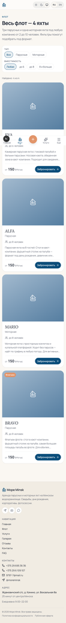

Флот — четыре яхты

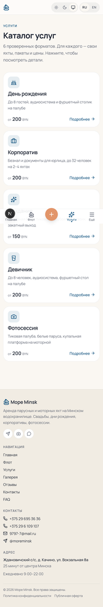

Услуги — индекс без «Свадьбы»

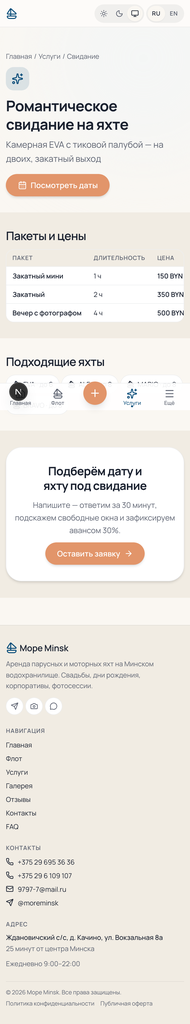

Свидание — от 150 BYN, три пакета

### 3.2 Mobile — остальные четыре услуги

[figure not shown]

День рождения — от 200, два пакета

[figure not shown]

Корпоратив

[figure not shown]

Девичник

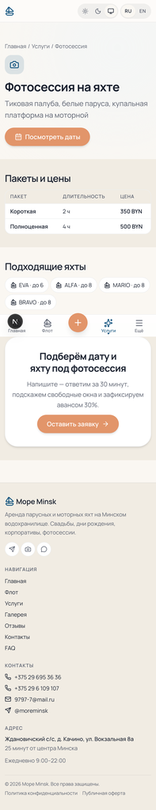

Фотосессия

### 3.3 Desktop — главная, услуги, свидание

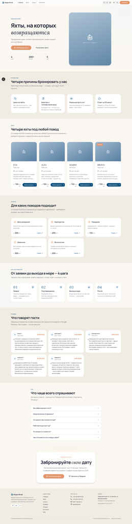

Главная — десктоп

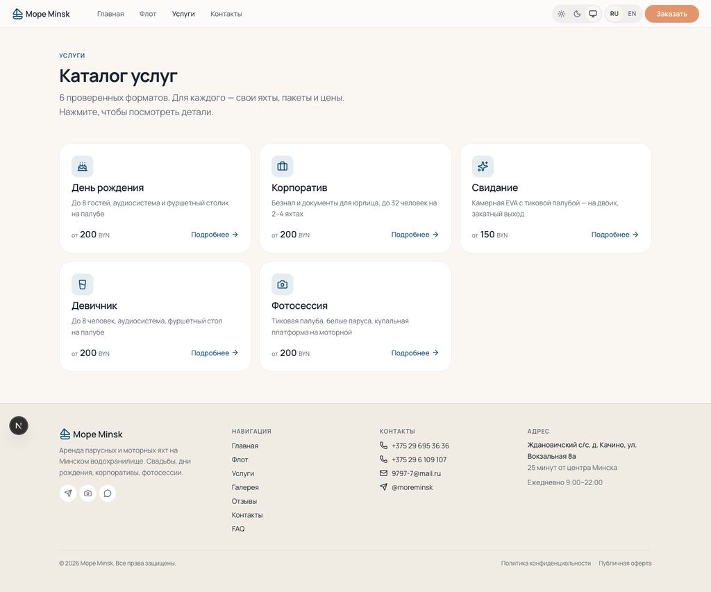

Услуги — десктоп

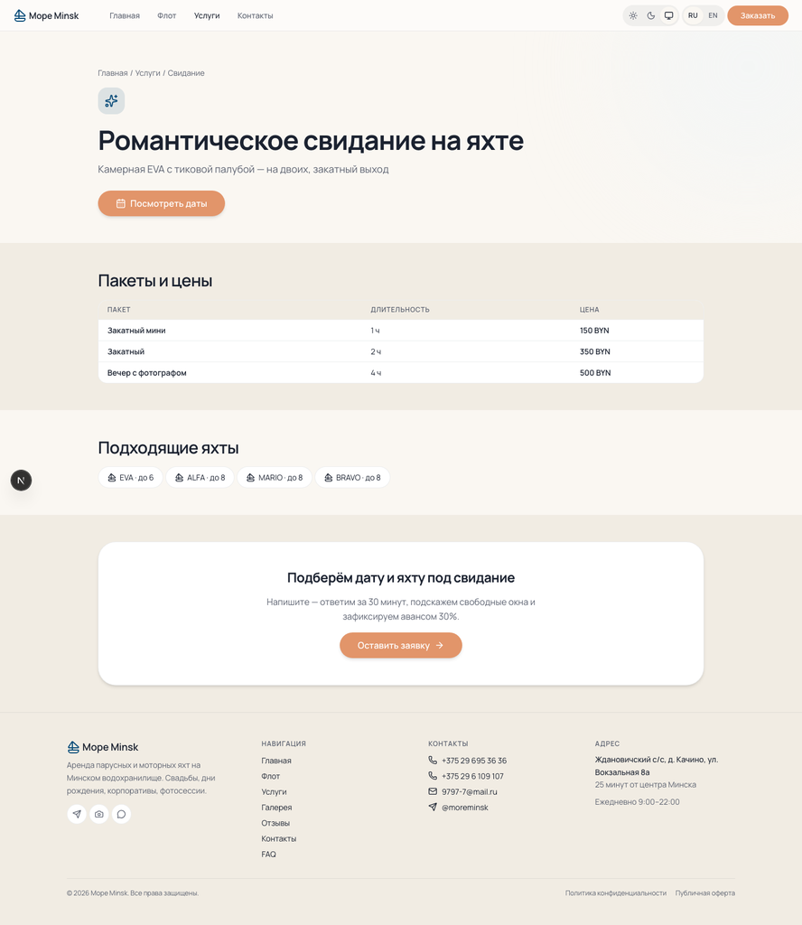

Свидание — десктоп

## 4. Что нужно от тебя сейчас

1. **Подтвердить «от 200 / от 150» как маркетинговую цену** (вариант А выше) — или сказать «нет, ставь по факту от 350». Без этого карточки выглядят честно, но Роман просил конкретные цифры.
2. **Сказать, есть ли исключения по яхтам.** Если девичник никогда не должен идти на моторной — мы это закладываем, не вопрос.
3. **Доступ к домену `moreminsk.by`.** Кто у тебя администратор у регистратора (предположительно hoster.by или nic.by)? Нам нужны DNS-настройки на 15 минут — после этого сайт на твоём домене.
4. **Доступ к Google Search Console** для домена (если уже подключал ранее) — чтобы сразу подать sitemap. Если нет — мы подключим под своим аккаунтом, потом передадим тебе.

## 5. Что у тебя на руках после этого ревью

- **PDF-отчёт** (этот документ) — можно открыть с телефона, переслать в чат, оставить себе как срез проекта.
- **Сайт по тех-адресу** — `https://uladzimir23.github.io/moreminsk/` — открывается прямо сейчас.
- **Все правки уже в коде** и закоммичены. После твоих ответов по п. 4 — переключаем на домен и подаём в Google.

## 6. Что обсудим в следующий раз

1. Цены — **подтверждение или ровная корректировка** (по результатам п. 4.1).
2. Контент — есть ли свежие **фото** и **видео** яхт сезона 2026, которые стоит добавить вместо «парсенных» с moreminsk.by.
3. Отзывы — 5 заглушек на сайте; можно ли запросить **реальные отзывы** у клиентов лета 2025 / весны 2026 для замены.
4. Аналитика — заводим **Яндекс.Метрику + Google Analytics** до или после запуска на домен.